# Module 0. Foundations refresher: R and regression

Slides

## Why a regression refresher comes first

- Every longitudinal model in this course is a regression with something added
- Mixed models add terms for people; GEE adds corrected standard errors
- This module: one row per participant (cross-sectional)
- It ends with the reason that is not enough

**Simulated data**

All examples use simulated data from fictional studies. Results illustrate methods; they are not empirical findings.

## Learning outcomes

1. **0.1** Open the course R project, load data with relative paths and inspect data frames with `dplyr`.
2. **0.2** Fit linear and logistic regression and interpret each coefficient, CI and p-value in outcome units.
3. **0.3** Specify and interpret a categorical-by-continuous interaction.
4. **0.4** Produce and interpret residual-vs-fitted and Q–Q plots, and name the assumption each checks.
5. **0.5** Explain a confidence interval for a mean vs a prediction interval for a new observation.

# Working in R

## Open the project; refer to files relative to its root

```r
# Open LDA_course.Rproj, then in any script or document:
source(here::here("R", "setup.R"))        # packages, theme, helpers
walk_raw  <- read_csv(here("data", "walk_baseline.csv"))
walk_base <- load_walk("baseline")         # same data, factors set
```

- `here()` builds paths from the project root, wherever the folder lives
- Never `setwd("C:/Users/me/...")`: it breaks on every other computer
- `load_walk()` sets reference levels: usual care first, male first

## Five `dplyr` verbs do most of the work

```r
walk_base |>
  group_by(arm) |>
  summarise(n = n(), mean_age = mean(age),
            pct_women = 100 * mean(sex == "Female"),
            mean_sbp0 = mean(sbp0), pct_150 = 100 * mean(hyp150))
```

```
#> # A tibble: 3 × 6
#>   arm       n mean_age pct_women mean_sbp0 pct_150
#>   <fct> <int>    <dbl>     <dbl>     <dbl>   <dbl>
#> 1 UC      120    59.62     54.17     146.2   40.83
#> 2 SP      120    60.11     56.67     147.2   45
#> 3 EP      120    60.52     47.5      147.5   48.33
```

`filter()` rows, `select()` columns, `mutate()` new columns, `group_by()` + `summarise()`, `arrange()`/`count()`

## `ggplot2` builds figures in layers

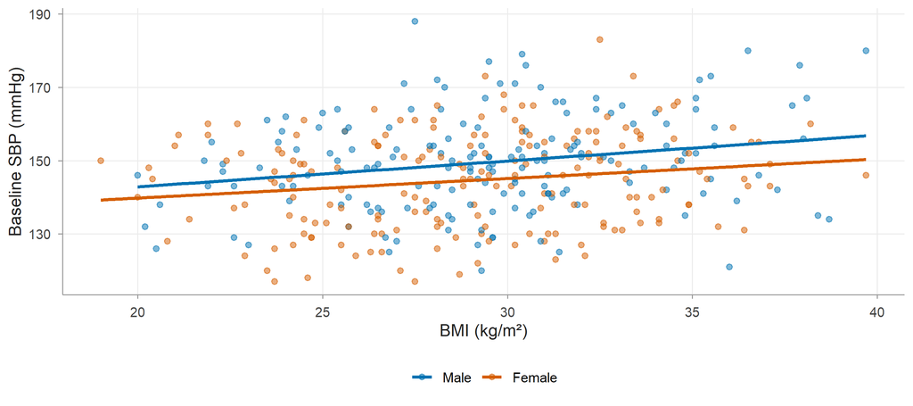

```r
ggplot(walk_base, aes(bmi, sbp0, colour = sex)) +
  geom_point(alpha = 0.5) +
  geom_smooth(method = "lm", se = FALSE, formula = y ~ x) +
  scale_colour_manual(values = sex_cols, name = NULL) +
  labs(x = "BMI (kg/m²)", y = "Baseline SBP (mmHg)")
```

## Try it

Workbook **Exercise 1**: open the project, load the baseline data, summarise by sex and draw a histogram of baseline SBP.

# Linear regression

## The question: how is baseline SBP associated with age, sex and BMI?

$$y_i = \beta_0 + \beta_1\,\text{age10}_i + \beta_2\,\text{Female}_i + \beta_3\,\text{bmi\_c}_i + \varepsilon_i,\quad \varepsilon_i \sim N(0,\sigma^2)$$

- $\beta_0$: mean SBP for a 60-year-old man with BMI 29 (all predictors zero)
- $\beta_1, \beta_2, \beta_3$: adjusted differences in mean SBP, in mmHg
- $\varepsilon_i$: residual; independent, constant variance $\sigma^2$

## Fitting is one line; reading the output is the skill

```r
m_lin <- lm(sbp0 ~ age10 + sex + bmi_c, data = walk_base)
round(cbind(coef(summary(m_lin))[, c(1, 2, 4)], confint(m_lin)), 3)
```

```
#>             Estimate Std. Error Pr(>|t|)   2.5 %  97.5 %
#> (Intercept)  149.322      0.984    0.000 147.386 151.257
#> age10          1.372      0.757    0.071  -0.116   2.861
#> sexFemale     -4.809      1.353    0.000  -7.470  -2.148
#> bmi_c          0.625      0.160    0.000   0.309   0.940
```

Residual SD 12.8 mmHg; $R^2$ = 0.082

## Each coefficient in words, with its interval

| Term | Estimate (95% CI), mmHg | Reading |
| --- | --- | --- |
| `age10` | 1.4 (-0.1 to 2.9) | per 10 years, same sex and BMI |
| `sexFemale` | -4.8 (-7.5 to -2.1) | women minus men, same age and BMI |
| `bmi_c` | 0.62 (0.31 to 0.94) | per 1 kg/m², same age and sex |

- CI: values of the true coefficient compatible with the data
- p-value: how surprising the estimate would be if the true value were 0
- True values (known because simulated): 3.0, −4.0, 0.6. The age truth lies just outside its interval: 1 in 20 intervals miss

## Centring changes the intercept, not the slopes

```r
m_raw <- lm(sbp0 ~ age + sex + bmi, data = walk_base)
rbind(centred = coef(m_lin), raw = coef(m_raw)) |> round(3)
```

```
#>         (Intercept) age10 sexFemale bmi_c
#> centred       149.3 1.372    -4.809 0.625
#> raw           123.0 0.137    -4.809 0.625
```

- Raw intercept 123 mmHg = a man aged 0 with BMI 0
- Slopes identical (age per year vs per decade)
- Centring will matter a lot once there are interactions

## Categorical predictors: K levels, K − 1 indicators

```r
m_arm <- lm(sbp0 ~ arm, data = walk_base)
round(coef(m_arm), 2)
```

```
#> (Intercept)       armSP       armEP
#>      146.18        1.03        1.35
```

```r
round(coef(lm(sbp0 ~ relevel(arm, ref = "EP"), data = walk_base)), 2)
```

```
#>                (Intercept) relevel(arm, ref = "EP")UC
#>                     147.53                      -1.35
#> relevel(arm, ref = "EP")SP
#>                      -0.33
```

- Each coefficient compares a level with the reference
- `relevel()` changes the comparison, not the model
- Baseline arm differences are chance: arm was randomised

## Residual plots check two assumptions; neither checks independence

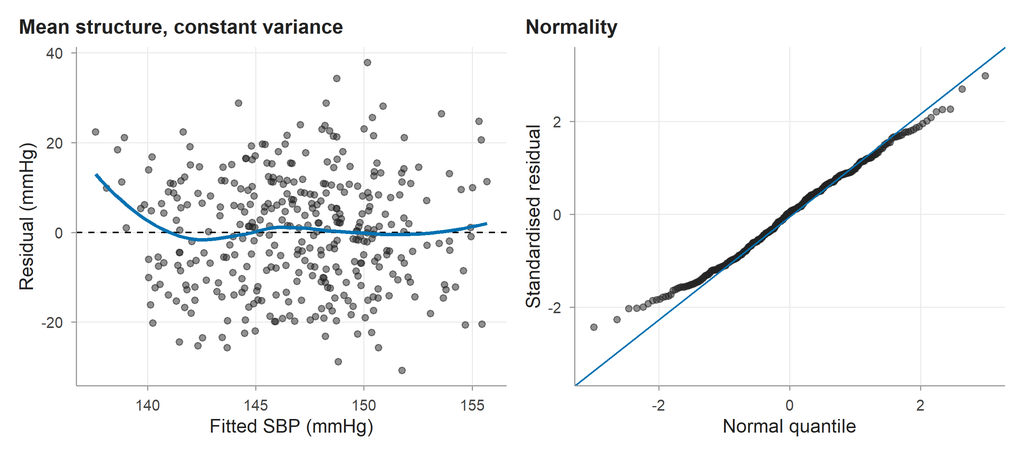

## Reporting a linear regression

**Reporting example**

Mean baseline SBP was 0.62 (0.31 to 0.94) mmHg higher per 1 kg/m² of BMI (p < 0.001) and -4.8 (-7.5 to -2.1) mmHg different in women than men (p < 0.001), adjusted for age and sex or BMI. The model explained 8.2% of the variance (residual SD 12.8 mmHg).

## Try it

Workbook **Exercises 2 and 3**: fit and interpret `sbp0 ~ age10 + sex + bmi_c`, then change reference levels.

# Interactions

## An interaction lets a slope differ between groups

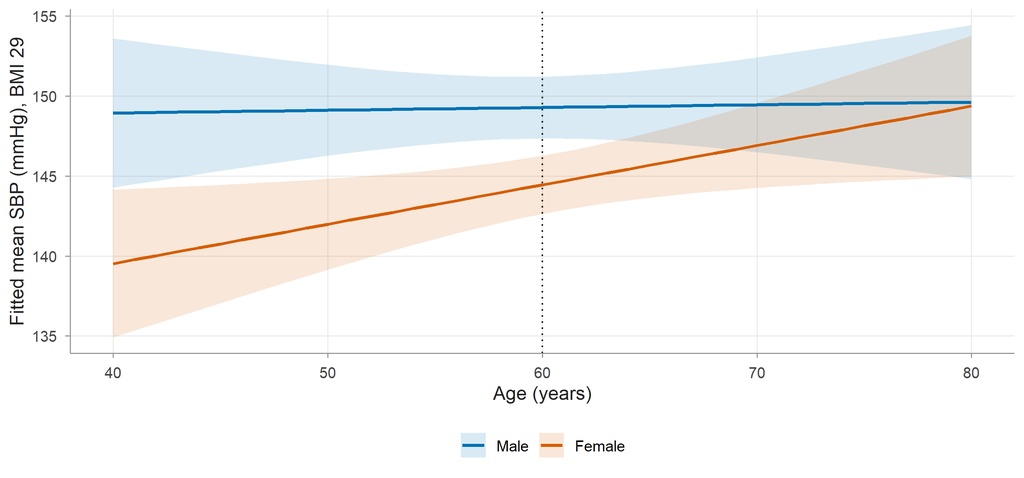

## Write out the mean for each group to read the coefficients

$$y_i = \beta_0 + \beta_1\,\text{age10}_i + \beta_2\,\text{Female}_i + \beta_3\,\text{bmi\_c}_i + \beta_4\,\text{age10}_i\,\text{Female}_i + \varepsilon_i$$

- Men: intercept $\beta_0$, age slope $\beta_1$
- Women: intercept $\beta_0 + \beta_2$, age slope $\beta_1 + \beta_4$
- $\beta_4$ = difference in slopes; $\beta_2$ = sex difference **at age 60**

## The interaction estimate is imprecise here

```r
m_int <- lm(sbp0 ~ age10 * sex + bmi_c, data = walk_base)
round(cbind(est = coef(m_int), confint(m_int)), 2)
```

```
#>                    est  2.5 % 97.5 %
#> (Intercept)     149.28 147.35 151.22
#> age10             0.17  -2.00   2.34
#> sexFemale        -4.83  -7.49  -2.18
#> bmi_c             0.59   0.27   0.91
#> age10:sexFemale   2.29  -0.72   5.30
```

```r
emtrends(m_int, ~ sex, var = "age10")
```

```
#>  sex    age10.trend   SE  df lower.CL upper.CL
#>  Male          0.17 1.10 355   -1.997     2.34
#>  Female        2.46 1.05 355    0.399     4.52
#>
#> Confidence level used: 0.95
```

## Without centring, the “main effect” refers to age 0

```r
m_int_raw <- lm(sbp0 ~ age * sex + bmi_c, data = walk_base)
round(coef(summary(m_int_raw))["sexFemale", ], 2)
```

```
#>   Estimate Std. Error    t value   Pr(>|t|)
#>     -18.58       9.29      -2.00       0.05
```

- Same model, same fitted values, same interaction
- `sexFemale` is now the sex difference for newborns: an extrapolation
- Centre continuous predictors so that zero is a value you care about

## Try it

Workbook **Exercise 4**: fit a BMI-by-sex interaction, centre BMI, and interpret every coefficient.

# Logistic regression

## Logistic regression models the log-odds

$$\log\frac{p_i}{1-p_i} = \beta_0 + \beta_1\,\text{age10}_i + \beta_2\,\text{Female}_i + \beta_3\,\text{bmi\_c}_i$$

- Outcome: baseline SBP ≥ 150 mmHg (161 of 360)
- $e^{\beta_k}$ = odds ratio for a one-unit difference
- No residual term: variance $p_i(1-p_i)$ follows from the mean

## Exponentiate estimates and limits to get odds ratios

```r
m_log <- glm(hyp150 ~ age10 + sex + bmi_c, family = binomial,
             data = walk_base)
round(exp(cbind(OR = coef(m_log), confint(m_log))), 3)
```

```
#>                OR 2.5 % 97.5 %
#> (Intercept) 0.972 0.716  1.320
#> age10       1.208 0.953  1.536
#> sexFemale   0.669 0.437  1.021
#> bmi_c       1.069 1.016  1.126
```

- BMI: odds × 1.069 per kg/m² (about 7% higher)
- Women: OR 0.67 (0.44 to 1.02)

## Predicted probabilities make odds ratios concrete

| profile | probability | lower | upper |
| --- | --- | --- | --- |
| Man, 60, BMI 29 | 0.49 | 0.42 | 0.57 |
| Woman, 60, BMI 29 | 0.39 | 0.33 | 0.47 |
| Woman, 70, BMI 35 | 0.54 | 0.42 | 0.65 |

- Interval computed on the log-odds scale, then transformed with `plogis()`
- Constant odds ratio, but the probability difference depends on the starting point

## Check a logistic model with calibration, not Q–Q plots

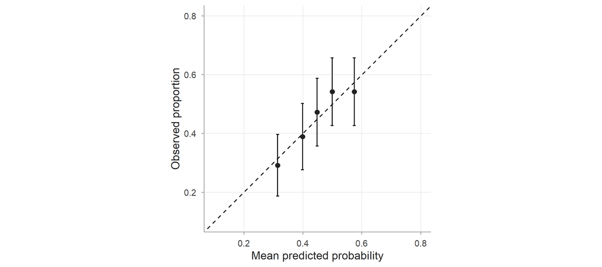

## Try it

Workbook **Exercise 5**: logistic regression for dropout, with odds ratios and predicted probabilities.

# Confidence and prediction intervals

## A mean is known more precisely than an individual

```r
new_men <- data.frame(age10 = 0, bmi_c = c(0, 6),
                      sex = factor("Male", levels = c("Male", "Female")))
predict(m_lin, new_men, interval = "confidence") |> round(1)
```

```
#>     fit   lwr   upr
#> 1 149.3 147.4 151.3
#> 2 153.1 150.5 155.7
```

```r
predict(m_lin, new_men, interval = "prediction") |> round(1)
```

```
#>     fit   lwr   upr
#> 1 149.3 124.1 174.5
#> 2 153.1 127.8 178.3
```

- Confidence interval: where the **mean** for such men lies
- Prediction interval: where **one new** man’s SBP lies; adds $\hat\sigma^2$

## The two bands answer two different questions

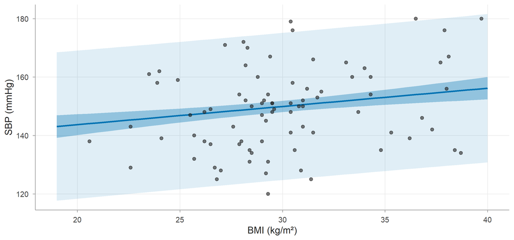

## Try it

Workbook **Exercise 6**: compute and plot both intervals for women aged 70.

# Why repeated measures change everything

## WALK measured the same people six times

```r
c(rows = nrow(walk), participants = n_distinct(walk$id))
```

```
#>         rows participants
#>         1897          360
```

```r
m_once <- lm(sbp0 ~ bmi, data = walk_base)
m_all  <- lm(sbp ~ bmi, data = walk)     # every visit as if independent
rbind(baseline_only = coef(summary(m_once))["bmi", 1:2],
      all_visits    = coef(summary(m_all))["bmi", 1:2]) |> round(3)
```

```
#>               Estimate Std. Error
#> baseline_only    0.647      0.163
#> all_visits       0.524      0.074
```

## Measurements on the same person are correlated

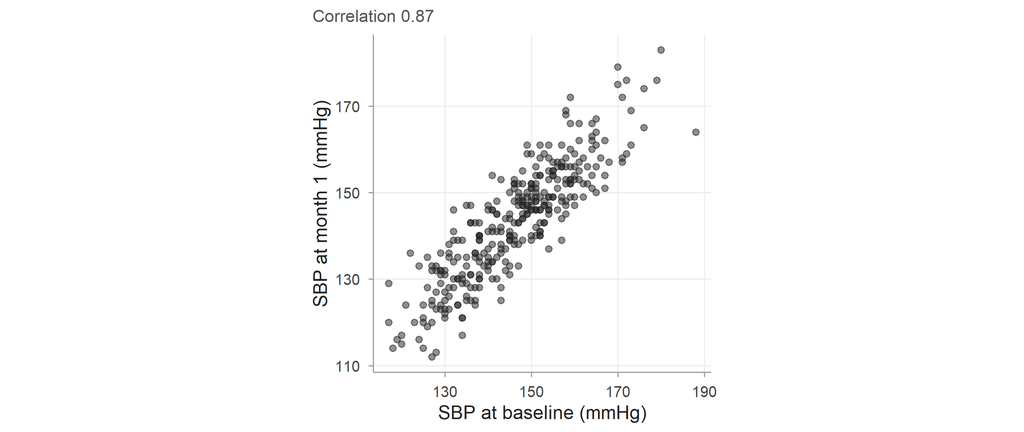

- Each person’s measurements share their personal level of SBP
- Treating them as independent makes **between-person** SEs too small
- For **within-person** comparisons (change over time) the error can go the other way

## Summary

- Coefficients are adjusted differences (linear) or odds ratios (logistic), always with units and intervals
- Centring moves the meaning of the intercept and of main effects under interactions
- Under an interaction, a main effect is the effect where the other variable is zero
- Residual-vs-fitted: mean and variance; Q–Q: normality; neither: independence
- CI for a mean vs PI for a new person
- Repeated measures violate independence: Module 1

## Further reading

- Gelman and Hill (2007), chapters 3–5: regression, interactions, centring
- Fitzmaurice et al. (2011), chapter 1: why longitudinal data need different methods
- Wickham (2014): tidy data

## References

Fitzmaurice, Garrett M., Nan M. Laird, and James H. Ware. 2011. *Applied Longitudinal Analysis*. 2nd edn. Wiley Series in Probability and Statistics. John Wiley & Sons. https://doi.org/10.1002/9781119513469.

Gelman, Andrew, and Jennifer Hill. 2007. *Data Analysis Using Regression and Multilevel/Hierarchical Models*. Analytical Methods for Social Research. Cambridge University Press. https://doi.org/10.1017/CBO9780511790942.

Wickham, Hadley. 2014. ‘Tidy Data’. *Journal of Statistical Software* 59 (10). https://doi.org/10.18637/jss.v059.i10.